# Credit Card Fraud Detection using R

# About the Dataset

## Context

It is essential for credit card companies to have the capability to detect fraudulent credit card transactions to ensure that customers are not held responsible for payments of items they did not acquire.

## Content

The dataset contains transactions made by credit cards in September 2013 by European cardholders. This dataset presents transactions that occurred in two days, where we have 492 frauds out of 284,807 transactions. The dataset is highly unbalanced, the positive class (frauds) account for 0.172% of all transactions.

## Transaction features

for a legitimate transaction, or the value 1

for a fraudulent transaction.

## Acknowledgements

The dataset has been collected and analysed during a research collaboration of Worldline and the Machine Learning Group (http://mlg.ulb.ac.be) of ULB (Université Libre de Bruxelles) on big data mining and fraud detection. More details on current and past projects on related topics are available on https://www.researchgate.net/project/Fraud-detection-5 and the page of the DefeatFraud project

## References

Andrea Dal Pozzolo, Olivier Caelen, Reid A. Johnson and Gianluca Bontempi. Calibrating Probability with Undersampling for Unbalanced Classification. In Symposium on Computational Intelligence and Data Mining (CIDM), IEEE, 2015

Dal Pozzolo, Andrea; Caelen, Olivier; Le Borgne, Yann-Ael; Waterschoot, Serge; Bontempi, Gianluca. Learned lessons in credit card fraud detection from a practitioner perspective, Expert systems with applications,41,10,4915-4928,2014, Pergamon

Dal Pozzolo, Andrea; Boracchi, Giacomo; Caelen, Olivier; Alippi, Cesare; Bontempi, Gianluca. Credit card fraud detection: a realistic modeling and a novel learning strategy, IEEE transactions on neural networks and learning systems,29,8,3784-3797,2018,IEEE

Dal Pozzolo, Andrea Adaptive Machine learning for credit card fraud detection ULB MLG PhD thesis (supervised by G. Bontempi)

Carcillo, Fabrizio; Dal Pozzolo, Andrea; Le Borgne, Yann-Aël; Caelen, Olivier; Mazzer, Yannis; Bontempi, Gianluca. Scarff: a scalable framework for streaming credit card fraud detection with Spark, Information fusion,41, 182-194,2018,Elsevier

Carcillo, Fabrizio; Le Borgne, Yann-Aël; Caelen, Olivier; Bontempi, Gianluca. Streaming active learning strategies for real-life credit card fraud detection: assessment and visualization, International Journal of Data Science and Analytics, 5,4,285-300,2018,Springer International Publishing

Bertrand Lebichot, Yann-Aël Le Borgne, Liyun He, Frederic Oblé, Gianluca Bontempi Deep-Learning Domain Adaptation Techniques for Credit Cards Fraud Detection, INNSBDDL 2019: Recent Advances in Big Data and Deep Learning, pp 78-88, 2019

Fabrizio Carcillo, Yann-Aël Le Borgne, Olivier Caelen, Frederic Oblé, Gianluca Bontempi Combining Unsupervised and Supervised Learning in Credit Card Fraud Detection Information Sciences, 2019

Yann-Aël Le Borgne, Gianluca Bontempi Reproducible machine Learning for Credit Card Fraud Detection - Practical Handbook

Bertrand Lebichot, Gianmarco Paldino, Wissam Siblini, Liyun He, Frederic Oblé, Gianluca Bontempi Incremental learning strategies for credit cards fraud detection, IInternational Journal of Data Science and Analytics

# DATA ANALYSIS PROCESS

View dataset

```r
head(creditcard)
```

| Time | V1 | V2 | V3 | V4 | V5 | V6 | V7 | V8 | V9 | V10 | V11 | V12 | V13 | V14 | V15 | V16 | V17 | V18 | V19 | V20 | V21 | V22 | V23 | V24 | V25 | V26 | V27 | V28 | Amount | … |
| --- | --- | --- | --- | --- | --- | --- | --- | --- | --- | --- | --- | --- | --- | --- | --- | --- | --- | --- | --- | --- | --- | --- | --- | --- | --- | --- | --- | --- | --- | --- |
| 0 | -1.3598071 | -0.07278117 | 2.5363467 | 1.3781552 | -0.33832077 | 0.46238778 | 0.23959855 | 0.09869790 | 0.3637870 | 0.09079417 | -0.5515995 | -0.61780086 | -0.9913898 | -0.3111694 | 1.4681770 | -0.4704005 | 0.20797124 | 0.02579058 | 0.40399296 | 0.25141210 | -0.018306778 | 0.277837576 | -0.11047391 | 0.06692807 | 0.1285394 | -0.1891148 | 0.133558377 | -0.02105305 | 149.62 | … |
| 0 | 1.1918571 | 0.26615071 | 0.1664801 | 0.4481541 | 0.06001765 | -0.08236081 | -0.07880298 | 0.08510165 | -0.2554251 | -0.16697441 | 1.6127267 | 1.06523531 | 0.4890950 | -0.1437723 | 0.6355581 | 0.4639170 | -0.11480466 | -0.18336127 | -0.14578304 | -0.06908314 | -0.225775248 | -0.638671953 | 0.10128802 | -0.33984648 | 0.1671704 | 0.1258945 | -0.008983099 | 0.01472417 | 2.69 | … |
| 1 | -1.3583541 | -1.34016307 | 1.7732093 | 0.3797796 | -0.50319813 | 1.80049938 | 0.79146096 | 0.24767579 | -1.5146543 | 0.20764287 | 0.6245015 | 0.06608369 | 0.7172927 | -0.1659459 | 2.3458649 | -2.8900832 | 1.10996938 | -0.12135931 | -2.26185710 | 0.52497973 | 0.247998153 | 0.771679402 | 0.90941226 | -0.68928096 | -0.3276418 | -0.1390966 | -0.055352794 | -0.05975184 | 378.66 | … |
| 1 | -0.9662717 | -0.18522601 | 1.7929933 | -0.8632913 | -0.01030888 | 1.24720317 | 0.23760894 | 0.37743587 | -1.3870241 | -0.05495192 | -0.2264873 | 0.17822823 | 0.5077569 | -0.2879237 | -0.6314181 | -1.0596472 | -0.68409279 | 1.96577500 | -1.23262197 | -0.20803778 | -0.108300452 | 0.005273597 | -0.19032052 | -1.17557533 | 0.6473760 | -0.2219288 | 0.062722849 | 0.06145763 | 123.50 | … |
| 2 | -1.1582331 | 0.87773675 | 1.5487178 | 0.4030339 | -0.40719338 | 0.09592146 | 0.59294075 | -0.27053268 | 0.8177393 | 0.75307443 | -0.8228429 | 0.53819555 | 1.3458516 | -1.1196698 | 0.1751211 | -0.4514492 | -0.23703324 | -0.03819479 | 0.80348692 | 0.40854236 | -0.009430697 | 0.798278495 | -0.13745808 | 0.14126698 | -0.2060096 | 0.5022922 | 0.219422230 | 0.21515315 | 69.99 | … |
| 2 | -0.4259659 | 0.96052304 | 1.1411093 | -0.1682521 | 0.42098688 | -0.02972755 | 0.47620095 | 0.26031433 | -0.5686714 | -0.37140720 | 1.3412620 | 0.35989384 | -0.3580907 | -0.1371337 | 0.5176168 | 0.4017259 | -0.05813282 | 0.06865315 | -0.03319379 | 0.08496767 | -0.208253515 | -0.559824796 | -0.02639767 | -0.37142658 | -0.2327938 | 0.1059148 | 0.253844225 | 0.08108026 | 3.67 | … |

```r
colnames(creditcard)
```

```
 [1] "Time"   "V1"     "V2"     "V3"     "V4"     "V5"     "V6"     "V7"     "V8"
[10] "V9"     "V10"    "V11"    "V12"    "V13"    "V14"    "V15"    "V16"    "V17"
[19] "V18"    "V19"    "V20"    "V21"    "V22"    "V23"    "V24"    "V25"    "V26"
[28] "V27"    "V28"    "Amount" "Class"
```

```r
is.null(creditcard)
```

```
[1] FALSE
```

```r
dim(creditcard)
```

```
[1] 284807     31
```

```r
#View unique values in the data frame
unique(creditcard$Class)
```

```
[1] 0 1
```

##### The data is clean and ready to analyse

## Descriptive Analysis

```r
creditcard$Class <- as.character(creditcard$Class)
is.character(creditcard$Class)
```

```
[1] TRUE
```

```r
describe(creditcard)
```

```
creditcard

 31  Variables      284807  Observations
------------------------------------------------------------------------------------------
Time
       n  missing distinct     Info     Mean      Gmd      .05      .10      .25      .50
  284807        0   124592        1    94814    54472    25298    35027    54202    84692
     .75      .90      .95
  139320   157640   164143

lowest :      0      1      2      4      7, highest: 172785 172786 172787 172788 172792
------------------------------------------------------------------------------------------
V1
        n   missing  distinct      Info      Mean       Gmd       .05       .10       .25
   284807         0    275663         1 3.919e-15     1.928  -2.89915  -1.89327  -0.92037
      .50       .75       .90       .95
  0.01811   1.31564   2.01541   2.08122

lowest : -56.407510 -46.855047 -41.928738 -40.470142 -40.042537
highest:   2.430507   2.439207   2.446505   2.451888   2.454930
------------------------------------------------------------------------------------------
V2
        n   missing  distinct      Info      Mean       Gmd       .05       .10       .25
   284807         0    275663         1 5.683e-16     1.464  -1.97198  -1.35986  -0.59855
      .50       .75       .90       .95
  0.06549   0.80372   1.32663   1.80858

lowest : -72.71573 -63.34470 -60.46462 -50.38327 -48.06086
highest:  18.18363  18.90245  19.16724  21.46720  22.05773
------------------------------------------------------------------------------------------
V3
         n    missing   distinct       Info       Mean        Gmd        .05        .10
    284807          0     275663          1 -8.762e-15      1.599    -2.3897    -1.8026
       .25        .50        .75        .90        .95
   -0.8904     0.1798     1.0272     1.6762     2.0626

lowest : -48.325589 -33.680984 -32.965346 -32.454198 -31.813586
highest:   4.079168   4.101716   4.187811   4.226108   9.382558
------------------------------------------------------------------------------------------
V4
```

[output cut: 226 more lines]

```
  284807        0    32767        1    88.35    133.2     0.92     1.00     5.60    22.00
     .75      .90      .95
   77.16   203.00   365.00

lowest :     0.00     0.01     0.02     0.03     0.04
highest: 11898.09 12910.93 18910.00 19656.53 25691.16
------------------------------------------------------------------------------------------
Class
       n  missing distinct
  284807        0        2

Value           0      1
Frequency  284315    492
Proportion  0.998  0.002
------------------------------------------------------------------------------------------
```

```r
#get the difference between normal and fraudulent transactions
table(creditcard$Class)
```

```
     0      1
284315    492
```

```r
creditcard %>% count(Class)
```

| Class | n |
| --- | --- |
| 0 | 284315 |
| 1 | 492 |

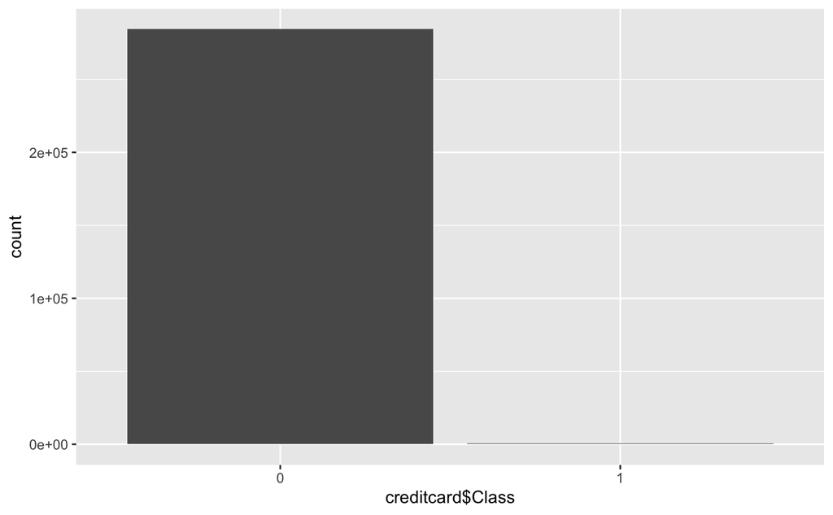

```r
ggplot(creditcard, aes(x = creditcard$Class)) + geom_bar()
```

| var | frequency | percentage | cumulative_perc |
| --- | --- | --- | --- |
| 0 | 284315 | 99.83 | 99.83 |
| 1 | 492 | 0.17 | 100.00 |

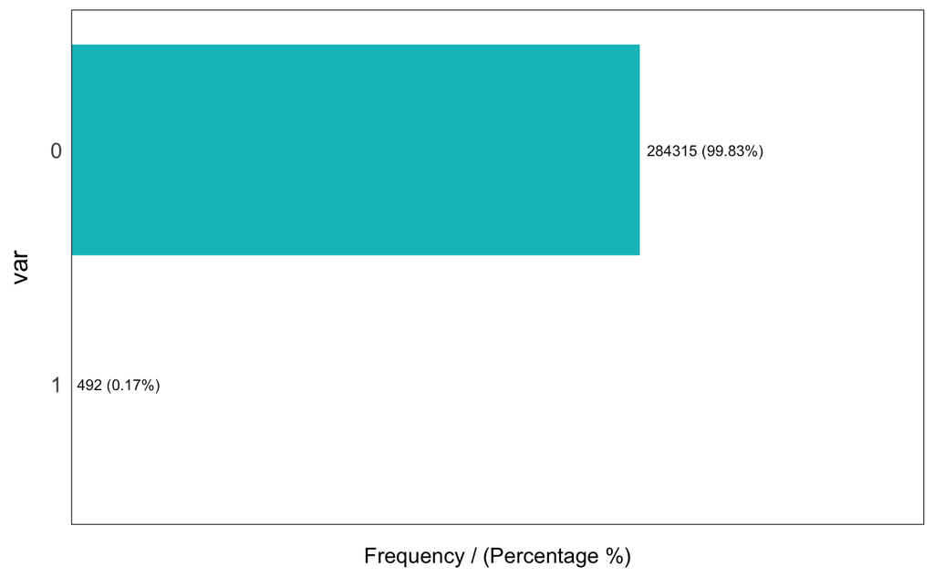

```r
freq(creditcard$Class)
```

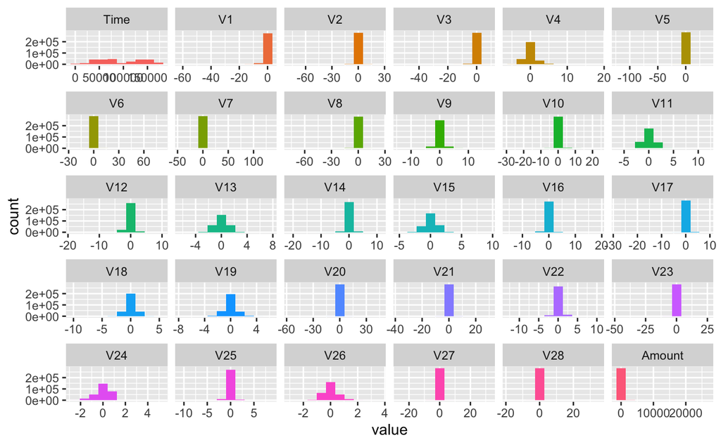

```r
#Step 3 - Analyzing numerical variables
plot_num(creditcard)
```

```r
#Try to identify high-unbalanced variables
```

```r
#Visually check any variable with outliers
data_prof=profiling_num(creditcard)

data_prof %>% select(variable, variation_coef, range_98)
```

| variable | variation_coef | range_98 |
| --- | --- | --- |
| Time | 5.008566e-01 | [2422, 170560.94] |
| V1 | 5.644117e+14 | [-6.5631993679757, 2.23712971071857] |
| V2 | 3.163889e+15 | [-4.96029977587028, 3.8018111875456] |
| V3 | -1.735073e+14 | [-3.97837667293219, 2.72843413510673] |
| V4 | 5.144896e+14 | [-3.12298669776242, 4.24803168084698] |
| V5 | -8.889700e+14 | [-3.0603956010352, 3.42490324792722] |
| V6 | 6.589208e+14 | [-2.12402347523507, 4.20008454199012] |
| V7 | -7.584534e+14 | [-3.01284693331828, 2.69620487724394] |
| V8 | -5.376094e+15 | [-4.03389863815991, 2.07597269543285] |
| V9 | -3.430350e+14 | [-2.45528762774549, 2.98677287918511] |

[output cut: 20 more lines]

```r
#A high value in variation_coef may indictate outliers. range_98 indicates where most of the values are.
```

## Plotting the data

```r
# Since it is in seconds, change to minute and hour, then do feature selection
# Change into time delta object and creates a time data class and out of that, convert into minutes and hours.

# convert seconds to hours and add new column

creditcard <- creditcard %>%
  mutate(hours = creditcard$Time/3600)
head(creditcard)
```

| Time | V1 | V2 | V3 | V4 | V5 | V6 | V7 | V8 | V9 | V10 | V11 | V12 | V13 | V14 | V15 | V16 | V17 | V18 | V19 | V20 | V21 | V22 | V23 | V24 | V25 | V26 | V27 | V28 | Amount | … |
| --- | --- | --- | --- | --- | --- | --- | --- | --- | --- | --- | --- | --- | --- | --- | --- | --- | --- | --- | --- | --- | --- | --- | --- | --- | --- | --- | --- | --- | --- | --- |
| 0 | -1.3598071 | -0.07278117 | 2.5363467 | 1.3781552 | -0.33832077 | 0.46238778 | 0.23959855 | 0.09869790 | 0.3637870 | 0.09079417 | -0.5515995 | -0.61780086 | -0.9913898 | -0.3111694 | 1.4681770 | -0.4704005 | 0.20797124 | 0.02579058 | 0.40399296 | 0.25141210 | -0.018306778 | 0.277837576 | -0.11047391 | 0.06692807 | 0.1285394 | -0.1891148 | 0.133558377 | -0.02105305 | 149.62 | … |
| 0 | 1.1918571 | 0.26615071 | 0.1664801 | 0.4481541 | 0.06001765 | -0.08236081 | -0.07880298 | 0.08510165 | -0.2554251 | -0.16697441 | 1.6127267 | 1.06523531 | 0.4890950 | -0.1437723 | 0.6355581 | 0.4639170 | -0.11480466 | -0.18336127 | -0.14578304 | -0.06908314 | -0.225775248 | -0.638671953 | 0.10128802 | -0.33984648 | 0.1671704 | 0.1258945 | -0.008983099 | 0.01472417 | 2.69 | … |
| 1 | -1.3583541 | -1.34016307 | 1.7732093 | 0.3797796 | -0.50319813 | 1.80049938 | 0.79146096 | 0.24767579 | -1.5146543 | 0.20764287 | 0.6245015 | 0.06608369 | 0.7172927 | -0.1659459 | 2.3458649 | -2.8900832 | 1.10996938 | -0.12135931 | -2.26185710 | 0.52497973 | 0.247998153 | 0.771679402 | 0.90941226 | -0.68928096 | -0.3276418 | -0.1390966 | -0.055352794 | -0.05975184 | 378.66 | … |
| 1 | -0.9662717 | -0.18522601 | 1.7929933 | -0.8632913 | -0.01030888 | 1.24720317 | 0.23760894 | 0.37743587 | -1.3870241 | -0.05495192 | -0.2264873 | 0.17822823 | 0.5077569 | -0.2879237 | -0.6314181 | -1.0596472 | -0.68409279 | 1.96577500 | -1.23262197 | -0.20803778 | -0.108300452 | 0.005273597 | -0.19032052 | -1.17557533 | 0.6473760 | -0.2219288 | 0.062722849 | 0.06145763 | 123.50 | … |
| 2 | -1.1582331 | 0.87773675 | 1.5487178 | 0.4030339 | -0.40719338 | 0.09592146 | 0.59294075 | -0.27053268 | 0.8177393 | 0.75307443 | -0.8228429 | 0.53819555 | 1.3458516 | -1.1196698 | 0.1751211 | -0.4514492 | -0.23703324 | -0.03819479 | 0.80348692 | 0.40854236 | -0.009430697 | 0.798278495 | -0.13745808 | 0.14126698 | -0.2060096 | 0.5022922 | 0.219422230 | 0.21515315 | 69.99 | … |
| 2 | -0.4259659 | 0.96052304 | 1.1411093 | -0.1682521 | 0.42098688 | -0.02972755 | 0.47620095 | 0.26031433 | -0.5686714 | -0.37140720 | 1.3412620 | 0.35989384 | -0.3580907 | -0.1371337 | 0.5176168 | 0.4017259 | -0.05813282 | 0.06865315 | -0.03319379 | 0.08496767 | -0.208253515 | -0.559824796 | -0.02639767 | -0.37142658 | -0.2327938 | 0.1059148 | 0.253844225 | 0.08108026 | 3.67 | … |

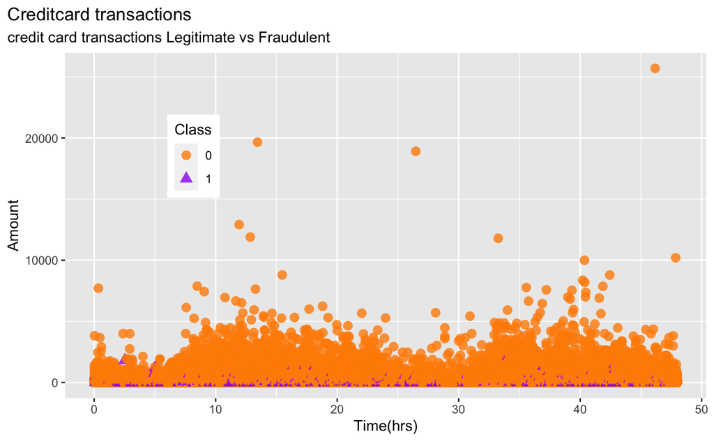

```r
#Legitimate vs Fraudulent transactions
ggplot(data = creditcard,
                       aes(x = creditcard$hours,
                           y = creditcard$Amount)) +
  geom_point(aes(color = creditcard$Class,
                 shape = creditcard$Class),
             size = 3,
             alpha = 0.8) +
  scale_color_manual(values = c("darkorange","purple")) +
  labs(title = "Creditcard transactions",
       subtitle = "credit card transactions Legitimate vs Fraudulent",
       x = "Time(hrs)",
       y = "Amount",
       color = "Class",
       shape = "Class") +
  theme(legend.position = c(0.2, 0.7),
        plot.title.position = "plot",
        plot.caption = element_text(hjust = 0, face= "italic"),
        plot.caption.position = "plot")
```

```
click left mouse button to proceed
```

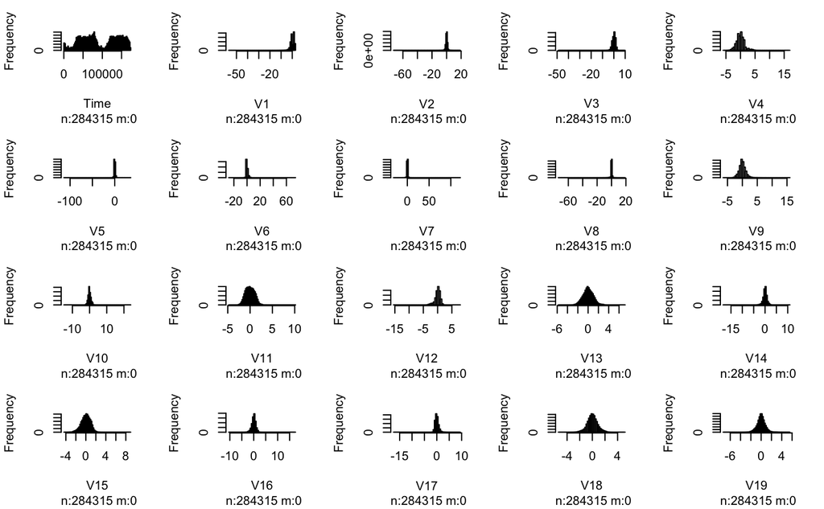

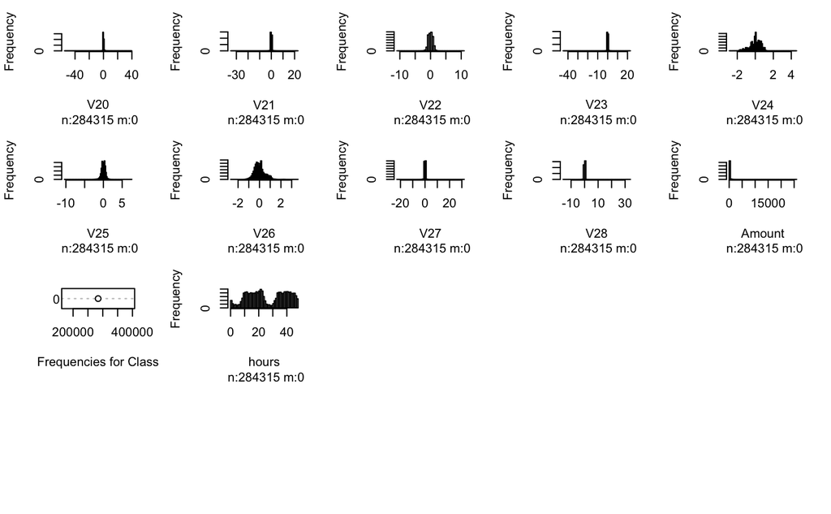

```r
hist(Legit_trans, breaks = 20)
```

```r
Fraud_trans <- filter(creditcard, creditcard$Class == 1)
print(Fraud_trans)
```

| Time | V1 | V2 | V3 | V4 | V5 | V6 | V7 | V8 | V9 | V10 | V11 | V12 | V13 | V14 | V15 | V16 | V17 | V18 | V19 | V20 | V21 | V22 | V23 | V24 | V25 | V26 | V27 | V28 | Amount | … |
| --- | --- | --- | --- | --- | --- | --- | --- | --- | --- | --- | --- | --- | --- | --- | --- | --- | --- | --- | --- | --- | --- | --- | --- | --- | --- | --- | --- | --- | --- | --- |
| 406 | -2.312226542 | 1.9519920106 | -1.609850732 | 3.99790559 | -0.522187865 | -1.426545319 | -2.537387306 | 1.391657e+00 | -2.770089277 | -2.77227214 | 3.2020332071 | -2.899907388 | -0.595221881 | -4.28925378 | 0.3897241203 | -1.14074718 | -2.83005567 | -0.01682247 | 0.416955705 | 0.126910559 | 0.517232371 | -0.035049369 | -4.652111e-01 | 0.320198199 | 4.451917e-02 | 0.1778397983 | 0.2611450026 | -0.143275875 | 0.00 | … |
| 472 | -3.043540624 | -3.1573071209 | 1.088462780 | 2.28864362 | 1.359805130 | -1.064822523 | 0.325574266 | -6.779365e-02 | -0.270952836 | -0.83858656 | -0.4145754483 | -0.503140860 | 0.676501545 | -1.69202893 | 2.0006348391 | 0.66677970 | 0.59971741 | 1.72532101 | 0.283344830 | 2.102338793 | 0.661695925 | 0.435477209 | 1.375966e+00 | -0.293803153 | 2.797980e-01 | -0.1453617148 | -0.2527731225 | 0.035764225 | 529.00 | … |
| 4462 | -2.303349568 | 1.7592474603 | -0.359744743 | 2.33024305 | -0.821628328 | -0.075787571 | 0.562319782 | -3.991466e-01 | -0.238253368 | -1.52541163 | 2.0329121576 | -6.560124295 | 0.022937323 | -1.47010154 | -0.6988260686 | -2.28219383 | -4.78183086 | -2.61566494 | -1.334441067 | -0.430021867 | -0.294166318 | -0.932391057 | 1.727263e-01 | -0.087329538 | -1.561143e-01 | -0.5426278890 | 0.0395659889 | -0.153028797 | 239.93 | … |
| 6986 | -4.397974442 | 1.3583670284 | -2.592844218 | 2.67978697 | -1.128130942 | -1.706536388 | -3.496197293 | -2.487777e-01 | -0.247767899 | -4.80163741 | 4.8958442235 | -10.912819319 | 0.184371686 | -6.77109672 | -0.0073261826 | -7.35808322 | -12.59841854 | -5.13154863 | 0.308333946 | -0.171607879 | 0.573574068 | 0.176967718 | -4.362069e-01 | -0.053501865 | 2.524053e-01 | -0.6574877548 | -0.8271357146 | 0.849573380 | 59.00 | … |
| 7519 | 1.234235046 | 3.0197404207 | -4.304596885 | 4.73279513 | 3.624200831 | -1.357745663 | 1.713444988 | -4.963585e-01 | -1.282857820 | -2.44746926 | 2.1013438650 | -4.609628391 | 1.464377625 | -6.07933719 | -0.3392373727 | 2.58185095 | 6.73938438 | 3.04249318 | -2.721853122 | 0.009060836 | -0.379068307 | -0.704181032 | -6.568048e-01 | -1.632652957 | 1.488901e+00 | 0.5667972735 | -0.0100162235 | 0.146792735 | 1.00 | … |
| 7526 | 0.008430365 | 4.1378368350 | -6.240696572 | 6.67573216 | 0.768307025 | -3.353059548 | -1.631734673 | 1.546124e-01 | -2.795892464 | -6.18789063 | 5.6643947086 | -9.854484823 | -0.306166658 | -10.69119621 | -0.6384981927 | -2.04197379 | -1.12905588 | 0.11645252 | -1.934665739 | 0.488378221 | 0.364514210 | -0.608057134 | -5.395279e-01 | 0.128939983 | 1.488481e+00 | 0.5079626778 | 0.7358216361 | 0.513573741 | 1.00 | … |
| 7535 | 0.026779226 | 4.1324638971 | -6.560599968 | 6.34855667 | 1.329665669 | -2.513478848 | -1.689102200 | 3.032528e-01 | -3.139409057 | -6.04546780 | 6.7546254481 | -8.948178579 | 0.702724998 | -10.73385410 | -1.3795198568 | -1.63896011 | -1.74635014 | 0.77674410 | -1.327356635 | 0.587743219 | 0.370508651 | -0.576752473 | -6.696054e-01 | -0.759907530 | 1.605056e+00 | 0.5406753964 | 0.7370403817 | 0.496699108 | 1.00 | … |
| 7543 | 0.329594333 | 3.7128892952 | -5.775935108 | 6.07826551 | 1.667359013 | -2.420168414 | -0.812891249 | 1.330801e-01 | -2.214311312 | -5.13445447 | 4.5607201055 | -8.873748362 | -0.797483600 | -9.17716637 | -0.2570247751 | -0.87168849 | 1.31301363 | 0.77391387 | -2.370599451 | 0.269772776 | 0.156617169 | -0.652450441 | -5.515722e-01 | -0.716521635 | 1.415717e+00 | 0.5552647398 | 0.5305073889 | 0.404474055 | 1.00 | … |
| 7551 | 0.316459000 | 3.8090759467 | -5.615159011 | 6.04744510 | 1.554025957 | -2.651353112 | -0.746579273 | 5.558631e-02 | -2.678678542 | -4.95949291 | 6.4390533516 | -7.520117393 | 0.386351667 | -9.25230725 | -1.3651884150 | -0.50236219 | 0.78442660 | 1.49430461 | -1.808012159 | 0.388307428 | 0.208828369 | -0.511746619 | -5.838132e-01 | -0.219845029 | 1.474753e+00 | 0.4911919257 | 0.5188682846 | 0.402528068 | 1.00 | … |
| 7610 | 0.725645740 | 2.3008944378 | -5.329976183 | 4.00768280 | -1.730410590 | -1.732192568 | -3.968592618 | 1.063728e+00 | -0.486096552 | -4.62498495 | 5.5887239147 | -7.148242636 | 1.680450741 | -6.21025775 | 0.4952821178 | -3.59954021 | -4.83032424 | -0.64909012 | 2.250123249 | 0.504646226 | 0.589669127 | 0.109541319 | 6.010453e-01 | -0.364700278 | -1.843078e+00 | 0.3519092984 | 0.5945499781 | 0.099372236 | 1.00 | … |

[output cut: 482 more lines]

```
click left mouse button to proceed
```

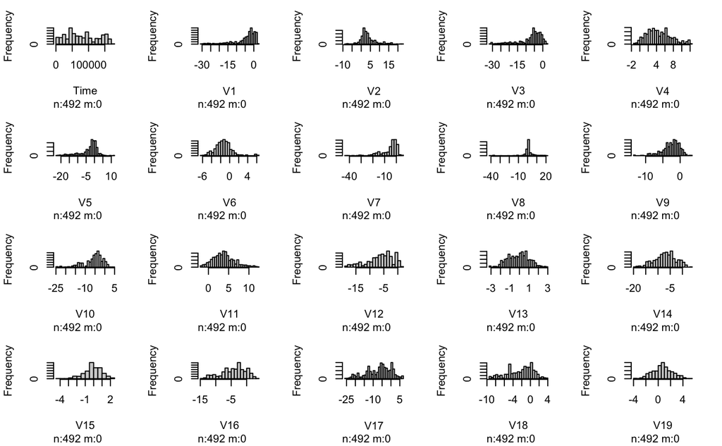

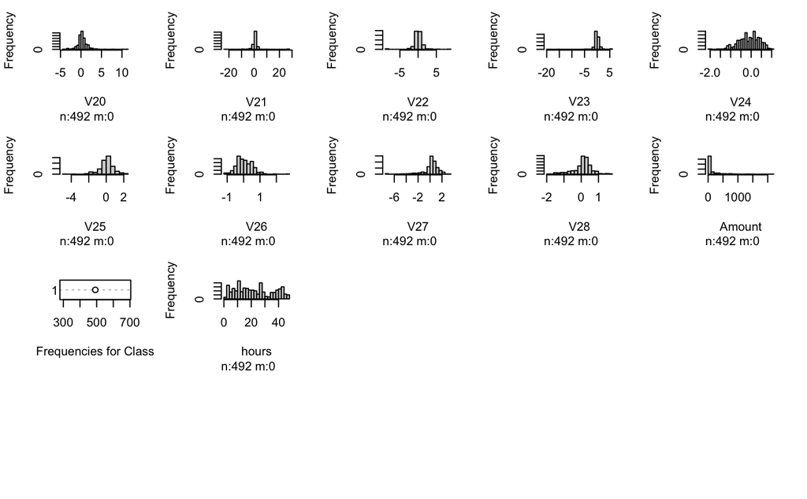

```r
# create a histogram with 20 bars
hist(Fraud_trans, breaks = 20)
```

```r
creditcard$Class <- as.numeric(creditcard$Class)
is.numeric(creditcard$Class)
```

```
[1] TRUE
```

Positive correlation (coefficient > 0) means that as one variable increases, the other variable tends to increase as well. Negative correlation (coefficient < 0) means that as one variable increases, the other variable tends to decrease. No correlation (coefficient = 0) means that there is no relationship between the two variables.

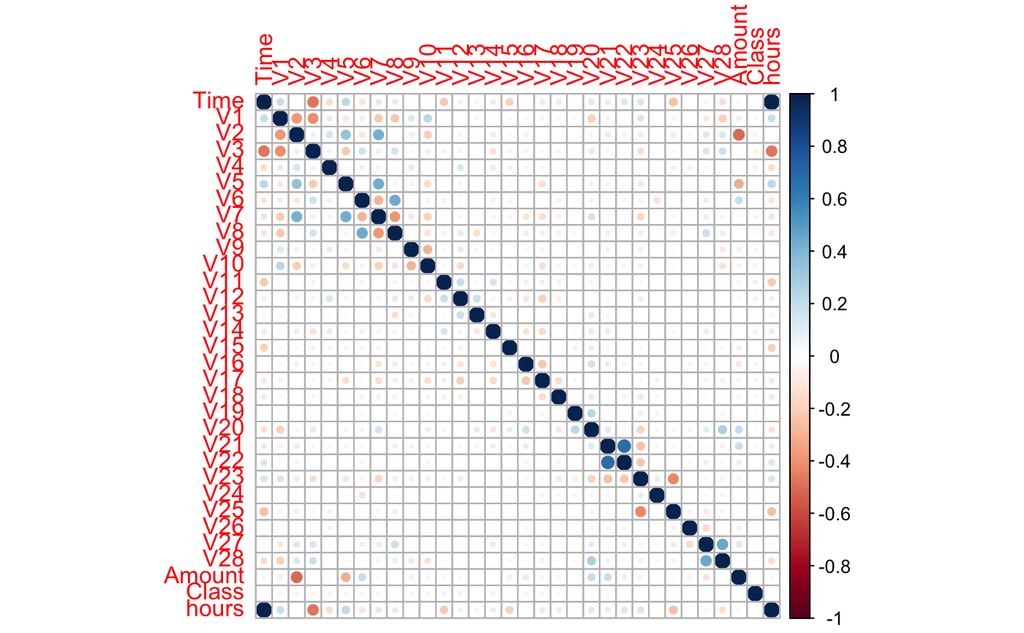

```r
creditcard.cor = cor(creditcard, method = c("spearman"))
corrplot(creditcard.cor)
```